# Coherence, Latent Semantic Analysis

Etienne Rolland

20/11/2019

## Discourse coherence

Language does not normally consist of isolated, unrelated sentences, but instead of collocated, structured, coherent groups of sentences. One possibility offered by computationnal linguistic is to compute the coherence of a discourse.

The coherence take the form of a value between 1 and 0, between two sentences, and can ne computed using the package LSAfun. For example :

```r
data(wonderland)

coherence ("There was certainly too much of it in the air. Even the Duchess
sneezed occasionally; and as for the baby, it was sneezing and howling
alternately without a moment's pause. The only things in the kitchen
that did not sneeze, were the cook, and a large cat which was sitting on
the hearth and grinning from ear to ear.",
tvectors=wonderland)
```

```
## $local
## [1] 0.5666128 0.5948014
##
## $global
## [1] 0.5807071
```

```r
# }
```

Considering that sentences are related between them inside section, the analysis of the coherence of a scientific article could highlight some breakpoints, corresponding to differents section.

## Coherence of sentences :

The article used is the first one in x, namely Adam et al, 2010, in the Biodistribution folder. The lines below isolate the sentences of the first documents, and remove the one with less than 8 caracters, to make the output of the analysis more clear.

```r
load("EN_100k_lsa.rda")
lsa=EN_100k_lsa

x <- readRDS(file = "annotation_gum.rds")
x <- as.data.frame(x)


sentences<-x[which(x$doc_id=="doc1"),]$sentence
sentences<-unique(sentences)
sentences<-sentences[which(nchar(sentences)>8)]
length(sentences)
```

```
## [1] 512
```

```r
for (sentence in sentences)
{
  sentence<-paste(sentence, "S3P4RAT0R", sep = "", collapse = NULL)
}
#"S3P4RAT0R" is a way to avoid the default behavior of the function which trim the input with the dot.
#otherwise, the coherence function output an object with a different lemght than the number of sentences.
```

Adding “S3P4RAT0R” is a way to avoid the default behavior of the function which trim the input with the dot. Otherwise, the coherence function output an object with a different lemght than the number of sentences.

```r
sentences[1]
```

```
## [1] "© The American Society of Gene & Cell Therapy"
```

Computing and plotting the coherence of the text :

```r
coherence<-coherence(sentences, split=c("S3P4RAT0R"), tvectors=lsa,breakdown=FALSE)
length(coherence$local)
```

```
## [1] 511
```

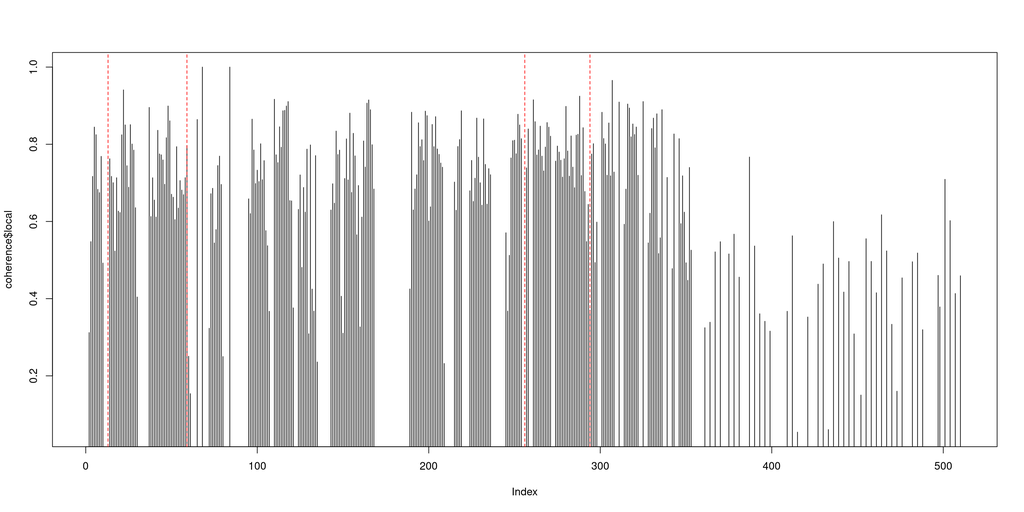

```r
plot(coherence$local, type="h")
abline(v=13, col="red", lty=2) #Introduction
abline(v=59, col="red", lty=2) #Results
abline(v=256, col="red", lty=2) #Discussion
abline(v=294, col="red", lty=2) #Materials and Methods Animals
```

```r
sentences[c(13, 59, 256, 294)]
```

```
## [1] "Introduction"
## [2] "Results LNP201 is a liposome assembly for systemic delivery of siRNA."
## [3] "Discussion"
## [4] "Materials and Methods Animals."
```

The annotation with the dashed line has been done manually.

## Coherence of paragraph

An other layer of complexity in the datastructure for NLP provided by UDpipe is the paragraph. The following section explore the same approach but for paragraph. Extracting them from the text require a bit of pre-processing.

```r
x<-x[which(x$doc_id=="doc1"),]

paragraph_id<-x[which(x$doc_id=="doc1"),]$paragraph_id
paragraph_id<-unique(paragraph_id)
max(paragraph_id)
```

```
## [1] 620
```

```r
all_paragraph<-c()

for (id in paragraph_id)
{
  paragraph<-x[which(x$paragraph_id==id),]$sentence
  paragraph<-unique(paragraph)
  paragraph<-do.call(paste, c(as.list(paragraph), sep = ""))
  all_paragraph<-c(all_paragraph, paragraph)
}


all_paragraph<-all_paragraph[which(nchar(all_paragraph)>8)]
txt_article<-do.call(paste, c(as.list(all_paragraph), sep = "S3P4RAT0R"))


coherence<-coherence(txt_article, split=c("S3P4RAT0R"), tvectors=lsa,breakdown=FALSE)
length(coherence$local)
```

```
## [1] 142
```

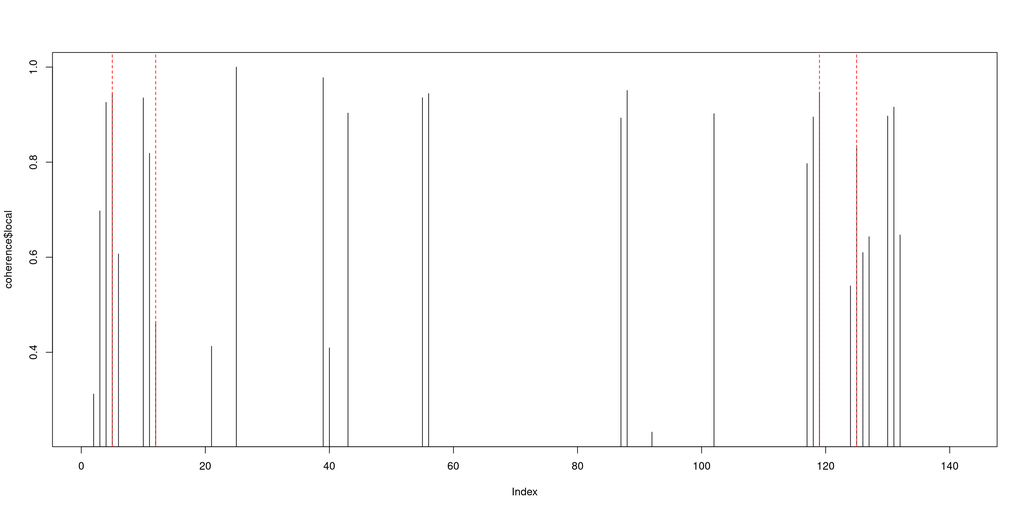

```r
plot(coherence$local, type="h")

abline(v=5, col="red", lty=2) #Introduction
abline(v=12, col="red", lty=2) #Results
abline(v=119, col="red", lty=2) #Discussion
abline(v=125, col="red", lty=2) #Materials and Methods Animals
```

```r
all_paragraph[c(5,12,119,125)]
```

```
## [1] "IntroductionTherapeutic small inhibitory RNAs (siRNAs) are an emerging modality for unmet medical needs because of their specificity, potency, reversibility, and large number of disease-relevant targets which are unreachable by conventional small molecules or monoclonal antibodies.siRNA appr…
## [2] "Results LNP201 is a liposome assembly for systemic delivery of siRNA.LNP201 is composed of the cationic lipid CLinDMA, cholesterol, and the helper lipid polyethylene glycol-dimyristoylglycerol at a molar ratio of 50:44:6 (Figure 1a).A chemically stabilized siRNA"
## [3] "DiscussionTherapeutic siRNAs have potential to make major contributions toward unmet medical needs in the coming years due to their virtually unlimited target space.Effective systemic siRNA delivery to the liver is an important advance, allowing for treatment of diabetes, hepatitis C infecti…
## [4] "Materials and Methods Animals.Female Crl:CD-1/ICR mice were obtained from Charles River"
```

## Sentence, but with an other semantic space

The computation of the discourse is made via a vector space created with Latent Semantic Analysis. The analysis of the first part used a already created lsa space. Here we redo the first analysis but with a vector space created on the corpus of text.

```r
lsa<-readRDS(file = "lsa_corpus.rds")



x <- readRDS(file = "annotation_gum.rds")
x <- as.data.frame(x)
length(unique(x$doc_id))
```

```
## [1] 751
```

```r
sentences<-x[which(x$doc_id=="doc1"),]$sentence
sentences<-unique(sentences)
sentences<-sentences[which(nchar(sentences)>8)]

for (sentence in sentences)
{
  sentence<-paste(sentence, "S3P4RAT0R", sep = "", collapse = NULL)
}
coherence<-coherence(sentences, split=c("S3P4RAT0R"), tvectors=lsa,breakdown=FALSE)
```

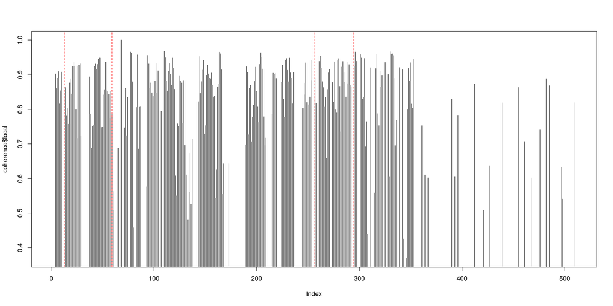

```r
plot(coherence$local, type="h")

abline(v=13, col="red", lty=2) #Introduction
abline(v=59, col="red", lty=2) #Results
abline(v=256, col="red", lty=2) #Discussion
abline(v=294, col="red", lty=2) #Materials and Methods Animals
```

```r
sentences[c(13, 59, 256, 294)]
```

```
## [1] "Introduction"
## [2] "Results LNP201 is a liposome assembly for systemic delivery of siRNA."
## [3] "Discussion"
## [4] "Materials and Methods Animals."
```